# 27기 이수정

0. 기본세팅

```r
#install.packages("plyr")
#install.packages("tidyverse")
#install.packages("data.table")
library(plyr)
library(tidyverse)
library(data.table)
#getwd()
setwd("C:/Users/user/Desktop/P-SAT/1주차패키지")
data<-fread('data.csv')
```

1. 데이터 확인

```r
str(data)
```

```
## Classes 'data.table' and 'data.frame':   5165 obs. of  8 variables:
##  $ patient_id    :integer64 1000000001 1000000002 1000000003 1000000004 1000000005 1000000006 1000000007 1000000008 ...
##  $ sex           : chr  "male" "male" "male" "male" ...
##  $ age           : chr  "50s" "30s" "50s" "20s" ...
##  $ country       : chr  "Korea" "Korea" "Korea" "Korea" ...
##  $ province      : chr  "서울" "서울" "서울" "서울" ...
##  $ city          : chr  "강서구" "중랑구" "종로구" "마포구" ...
##  $ confirmed_date: IDate, format: "2020-01-23" "2020-01-30" ...
##  $ state         : chr  "released" "released" "released" "released" ...
##  - attr(*, ".internal.selfref")=<externalptr>
```

```r
for (i in 1:8){
  print(sum(is.na(data[[i]])))
}
```

```
## [1] 0
## [1] 0
## [1] 0
## [1] 0
## [1] 0
## [1] 0
## [1] 3
## [1] 0
```

```r
for (j in 1:8){
  print(unique(data[[j]]))
  print(length(unique(data[[j]])))
}
```

```
## integer64
##    [1] 1000000001 1000000002 1000000003 1000000004 1000000005 1000000006
##    [7] 1000000007 1000000008 1000000009 1000000010 1000000011 1000000012
##   [13] 1000000013 1000000014 1000000015 1000000016 1000000017 1000000018
##   [19] 1000000019 1000000020 1000000021 1000000022 1000000023 1000000024
##   [25] 1000000025 1000000026 1000000027 1000000028 1000000029 1000000030
##   [31] 1000000031 1000000032 1000000033 1000000034 1000000035 1000000036
##   [37] 1000000037 1000000038 1000000039 1000000040 1000000041 1000000042
##   [43] 1000000043 1000000044 1000000045 1000000046 1000000047 1000000048
##   [49] 1000000049 1000000050 1000000051 1000000052 1000000053 1000000054
##   [55] 1000000055 1000000056 1000000057 1000000058 1000000059 1000000060
##   [61] 1000000061 1000000062 1000000063 1000000064 1000000065 1000000066
##   [67] 1000000067 1000000068 1000000069 1000000070 1000000071 1000000072
##   [73] 1000000073 1000000074 1000000075 1000000076 1000000077 1000000078
##   [79] 1000000079 1000000080 1000000081 1000000082 1000000083 1000000084
```

[output cut: 924 more lines]

2-1. NA가 있는 행을 삭제하세요.

```r
#아래 for문을 통해 원래 열의 행의 개수가 5165임을 알 수 있음
#for (i in 1:8){
#  print(length(data[[i]]))
#}

data<-na.omit(data)

#for (i in 1:8){
#  print(length(data[[i]]))
#}
#위의 for문을 통해 행3개가 삭제됨을 알 수 있음
```

2-2. 빈 문자열(“”)이 있는 행을 삭제하고, 각 열마다 NA 개수와 unique 값 및 개수를 다시 확인

```r
for (i in 2:6){
  data<-data[!(data[[i]]==""), ]
}

data<-data[!(data[[8]]==''),]

#for (i in 1:8){
#  print(length(data[[i]]))        #3690개
#}


for (i in 1:8){
  print(sum(is.na(data[[i]])))
}
```

```
## [1] 0
## [1] 0
## [1] 0
## [1] 0
## [1] 0
## [1] 0
## [1] 0
## [1] 0
```

```r
for (j in 1:8){
  print(unique(data[[j]]))
  print(length(unique(data[[j]])))
}
```

```
## integer64
##    [1] 1000000001 1000000002 1000000003 1000000004 1000000005 1000000006
##    [7] 1000000007 1000000008 1000000009 1000000010 1000000011 1000000012
##   [13] 1000000013 1000000014 1000000015 1000000016 1000000017 1000000018
##   [19] 1000000019 1000000020 1000000021 1000000022 1000000023 1000000024
##   [25] 1000000025 1000000026 1000000027 1000000028 1000000029 1000000030
##   [31] 1000000031 1000000032 1000000033 1000000034 1000000035 1000000036
##   [37] 1000000037 1000000038 1000000039 1000000040 1000000041 1000000042
##   [43] 1000000043 1000000044 1000000045 1000000046 1000000047 1000000048
##   [49] 1000000049 1000000050 1000000051 1000000052 1000000053 1000000054
##   [55] 1000000055 1000000056 1000000057 1000000058 1000000059 1000000060
##   [61] 1000000061 1000000062 1000000063 1000000064 1000000065 1000000066
##   [67] 1000000067 1000000068 1000000069 1000000070 1000000071 1000000072
##   [73] 1000000073 1000000074 1000000075 1000000076 1000000077 1000000078
##   [79] 1000000079 1000000080 1000000081 1000000082 1000000083 1000000084
```

[output cut: 676 more lines]

3. country가 ‘Korea’인 행만 남긴 다음, country 열을 제거하세요.

```r
data<-data[data$country=='Korea']
#length(data$country)#3653개로 줄어듬
data<-subset(data,select=-country)
#library(bit64)
#head(data) #dataframe에서 위의 6개 행을 볼 수 있다.따라서 열의 개수,열의 이름도 파악 가능(7개)
```

4. province 변수 내 ‘서울, 부산, 대구, 인천, 대전, 세종, 울산, 제주도’ 값을 다음과 같이 바꾸세요.

```r
data$province<-ifelse(data$province=='서울', '서울특별시',data$province)
data$province<-ifelse(data$province=='부산', '부산광역시',data$province)
data$province<-ifelse(data$province=='대구', '대구광역시',data$province)
data$province<-ifelse(data$province=='인천', '인천광역시',data$province)
data$province<-ifelse(data$province=='대전', '대전광역시',data$province)
data$province<-ifelse(data$province=='세종', '세종특별자치시',data$province)
data$province<-ifelse(data$province=='울산', '울산광역시',data$province)
data$province<-ifelse(data$province=='제주도', '제주특별자치도',data$province)
```

5. confirmed_date를 날짜 자료형(Date)으로 바꾸세요.

```r
as.Date(data$confirmed_date,format='%Y-%m-%d')
```

```
##    [1] "2020-01-23" "2020-01-30" "2020-01-30" "2020-01-30" "2020-01-31"
##    [6] "2020-01-31" "2020-01-31" "2020-02-02" "2020-02-05" "2020-02-05"
##   [11] "2020-02-07" "2020-02-16" "2020-02-16" "2020-02-19" "2020-02-19"
##   [16] "2020-02-20" "2020-02-20" "2020-02-20" "2020-02-20" "2020-02-20"
##   [21] "2020-02-21" "2020-02-21" "2020-02-22" "2020-02-22" "2020-02-22"
##   [26] "2020-02-23" "2020-02-23" "2020-02-26" "2020-02-22" "2020-02-23"
##   [31] "2020-02-24" "2020-02-24" "2020-02-25" "2020-02-25" "2020-02-25"
##   [36] "2020-02-25" "2020-02-25" "2020-02-25" "2020-02-26" "2020-02-26"
##   [41] "2020-02-26" "2020-02-26" "2020-02-26" "2020-02-26" "2020-02-26"
##   [46] "2020-02-26" "2020-02-27" "2020-02-27" "2020-02-27" "2020-02-27"
##   [51] "2020-02-27" "2020-02-27" "2020-02-27" "2020-02-27" "2020-02-27"
##   [56] "2020-02-28" "2020-02-28" "2020-02-28" "2020-02-28" "2020-02-29"
##   [61] "2020-02-29" "2020-02-29" "2020-02-29" "2020-02-29" "2020-02-29"
##   [66] "2020-02-27" "2020-02-27" "2020-02-26" "2020-02-27" "2020-02-27"
##   [71] "2020-02-27" "2020-02-27" "2020-02-27" "2020-02-28" "2020-02-25"
```

[output cut: 716 more lines]

6. 확진날짜(confirmed_date) 별 확진자 수에 대한 파생변수를 만드세요. (파생변수 이름 : confirmed_number)

```r
data1<-data%>%group_by(confirmed_date)%>%dplyr::summarize(confirmed_number = n())
data3<-inner_join(data,data1,by = "confirmed_date")
#data%>%group_by(confirmed_date)%>%mutate(confirmed_number=n())
```

7. 확진날짜(confirmed_date)의 주말 여부에 대한 파생변수를 만드세요. (파생변수 이름 : wday) 예 : 2021-03-05 -> 주중, 2021-03-06 -> 주말

```r
data3$wday <- ifelse(weekdays(data3$confirmed_date) == "토요일" | weekdays(data3$confirmed_date) == "일요일", "주말","주중")
```

8. 나이대 별 일별 확진자 수에 대한 summary를 확인해 보세요. (예 : 10대의 날짜별 확진자 수의 분포) (tapply 이용 시 편리)

```r
tapply(data3$confirmed_number, data3$age,summary)
```

```
## $`0s`
##    Min. 1st Qu.  Median    Mean 3rd Qu.    Max.
##    6.00   12.00   53.50   58.27   98.00  143.00
##
## $`100s`
##    Min. 1st Qu.  Median    Mean 3rd Qu.    Max.
##      95      95      95      95      95      95
##
## $`10s`
##    Min. 1st Qu.  Median    Mean 3rd Qu.    Max.
##    1.00   19.00   52.00   58.32   98.00  143.00
##
## $`20s`
##    Min. 1st Qu.  Median    Mean 3rd Qu.    Max.
##    1.00   42.00   57.00   67.65  110.00  143.00
##
## $`30s`
##    Min. 1st Qu.  Median    Mean 3rd Qu.    Max.
##    1.00   31.00   54.00   59.88   95.00  143.00
##
## $`40s`
##    Min. 1st Qu.  Median    Mean 3rd Qu.    Max.
##    1.00   38.00   65.00   68.95  110.00  143.00
##
## $`50s`
##    Min. 1st Qu.  Median    Mean 3rd Qu.    Max.
##    1.00   37.00   56.00   65.73   98.00  143.00
##
## $`60s`
##    Min. 1st Qu.  Median    Mean 3rd Qu.    Max.
##    2.00   31.00   55.00   60.76   95.00  143.00
##
## $`70s`
##    Min. 1st Qu.  Median    Mean 3rd Qu.    Max.
##    2.00   35.00   56.00   65.79   99.00  143.00
##
## $`80s`
##    Min. 1st Qu.  Median    Mean 3rd Qu.    Max.
##    2.00   47.00   72.00   78.67  115.00  143.00
##
## $`90s`
##    Min. 1st Qu.  Median    Mean 3rd Qu.    Max.
##   10.00   50.50   64.00   85.44  143.00  143.00
```

Chapter 2. 시각화 1 Line Plot. confirmed_date와 confirmed_number 변수를 이용하여 확진자수 추이 그래프를 그리고, 최대 확진자에 대한 정보도 표시하세요. (적절한 함수를 이용하여 #대신 정확한 날짜 및 수를 쓸 것 , 색:navy, lightblue, 제목:bold체)

[figure not shown]

```r
data3%>%ggplot(aes(x=confirmed_date, y=confirmed_number)) +
  geom_line(color='lightblue')+
  ggtitle("코로나 확진자 수 추이-국내인 기준")+
  theme(plot.title=element_text(face='bold',hjust=0.5))+
  geom_text(x=as.Date("2020-02-05"),y=145,label='2020-03-05(145명)',color='navy')+ geom_point(mapping =aes(x = as.Date('2020-03-05'), y =145), color="navy");
```

1-2 Line Plot. province 별 확진자 수 추이 그래프를 그리세요.

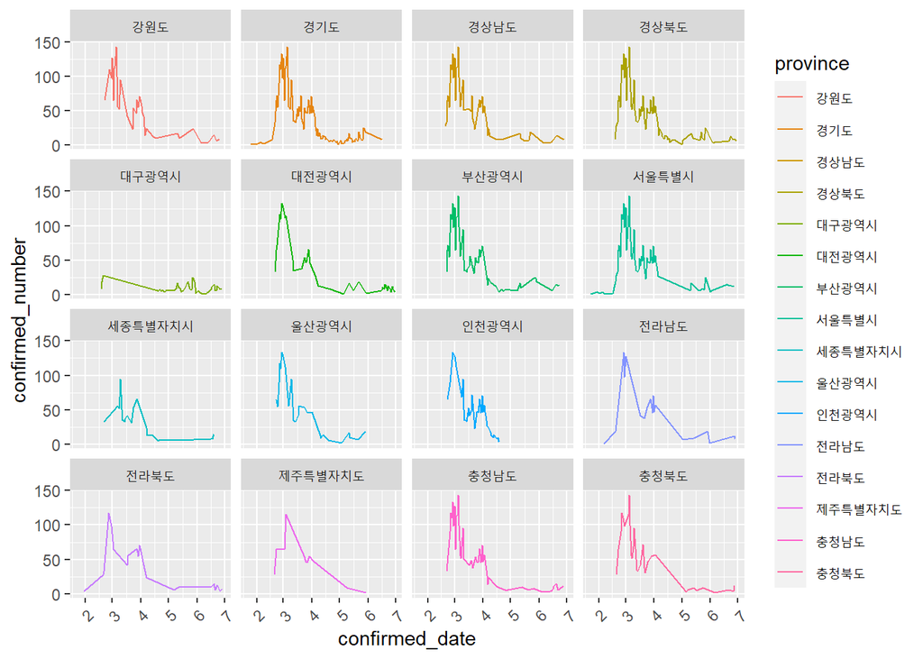

```r
data3%>%ggplot()+aes(x=confirmed_date, y=confirmed_number,col=province)+geom_line()+
  facet_wrap(~province)+
  theme(axis.text.x=element_text(angle=45, hjust=1))
```

2 Bar Plot. 지역별 확진자 수를 state(확진자 상황) 그룹 별로 나누어 그래프를 그리세요.

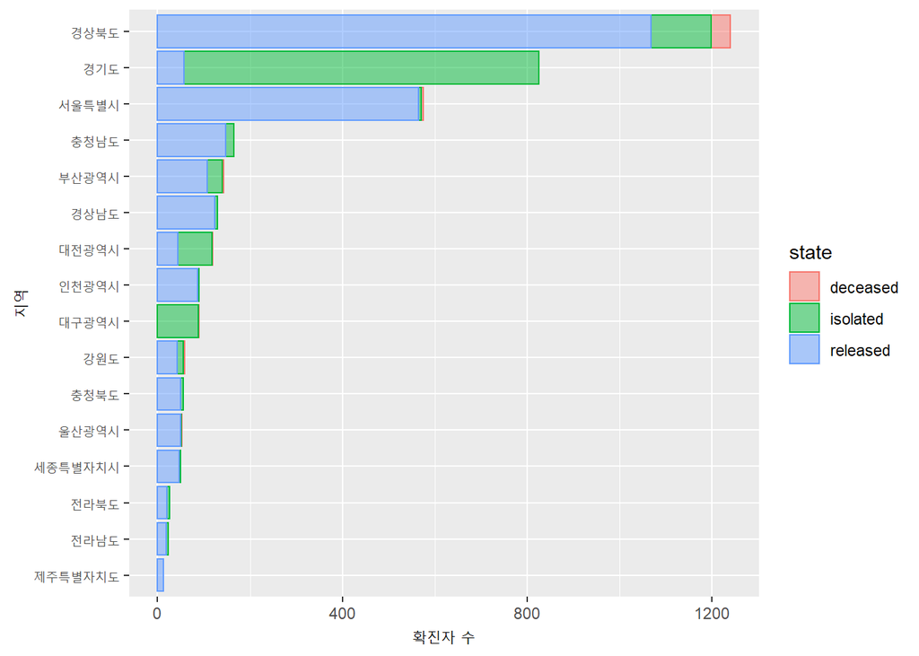

```r
data_prov = data3 %>% group_by(province)%>%summarize(n = n())

data3 %>%
  left_join(data_prov,by = 'province') %>%
  ggplot(aes(x = reorder(province,n))) +
  geom_bar(aes(fill = state, color = state), position = 'stack', alpha = 0.5) +
  xlab('지역')+
  ylab('확진자 수')+
  coord_flip()
```

3. Box Plot. 나이대별 일별 확진자 수 box plot을 그리세요

```r
data_age<-data%>%group_by(age,confirmed_date)%>%dplyr::summarize(count = n())
```

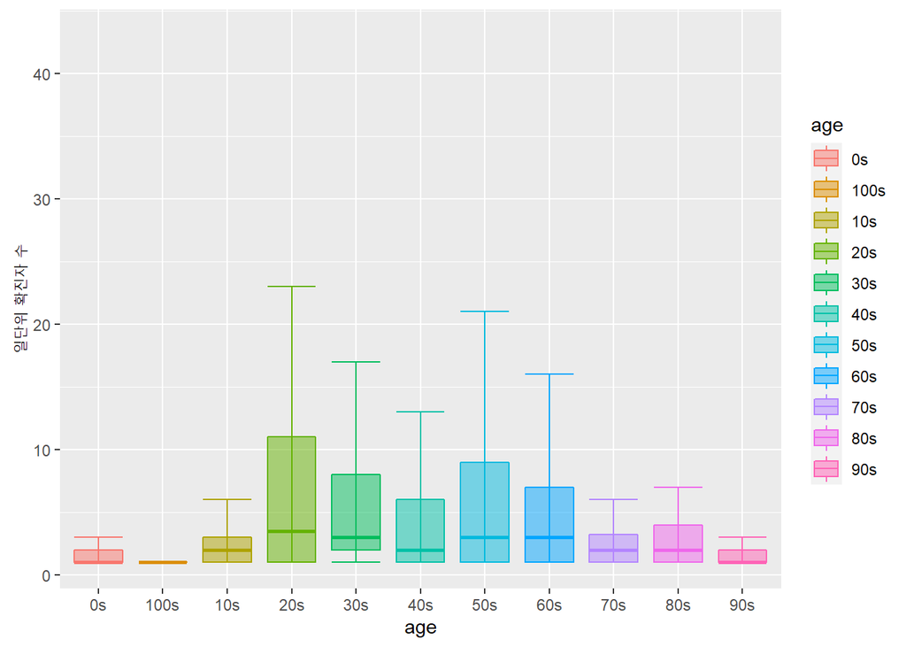

```r
data_age2<-inner_join(data,data_age, by='age')

data_age2%>%ggplot(aes(x = age,y= count,fill = age,color=age))+
  geom_boxplot(outlier.shape = NA,alpha=0.5)+
  stat_boxplot(geom="errorbar")+
  xlab('age')+
  ylab('일단위 확진자 수')
```

3-2 . 나이대별 일별 확진자 수에 대한 일원분산분석(one-way ANOVA)을 실시하여 해석해 보세요.

```r
aov(confirmed_number ~ age, data = data3)
```

```
## Call:
##    aov(formula = confirmed_number ~ age, data = data3)
##
## Terms:
##                     age Residuals
## Sum of Squares    96460   5942081
## Deg. of Freedom      10      3642
##
## Residual standard error: 40.39237
## Estimated effects may be unbalanced
```

```r
summary(aov(confirmed_number ~ age, data = data3))
```

```
##               Df  Sum Sq Mean Sq F value   Pr(>F)
## age           10   96460    9646   5.912 6.35e-09 ***
## Residuals   3642 5942081    1632
## ---
## Signif. codes:  0 '***' 0.001 '**' 0.01 '*' 0.05 '.' 0.1 ' ' 1
```

Chapter 3. 모델링_회귀분석 MASS, tidyverse(다시 부를 필요 없음),corrplot, caret, MLmetrics 패키지

```r
#install.packages('MASS')
#install.packages("corrplot")
#install.packages('caret')
#install.packages('MLmetrics')

library(MASS)
library(corrplot)
library(caret)
library(MLmetrics)
df<-Boston
```

1. 아래처럼 상관계수 플랏을 만들고 간단히 해석해 보세요.

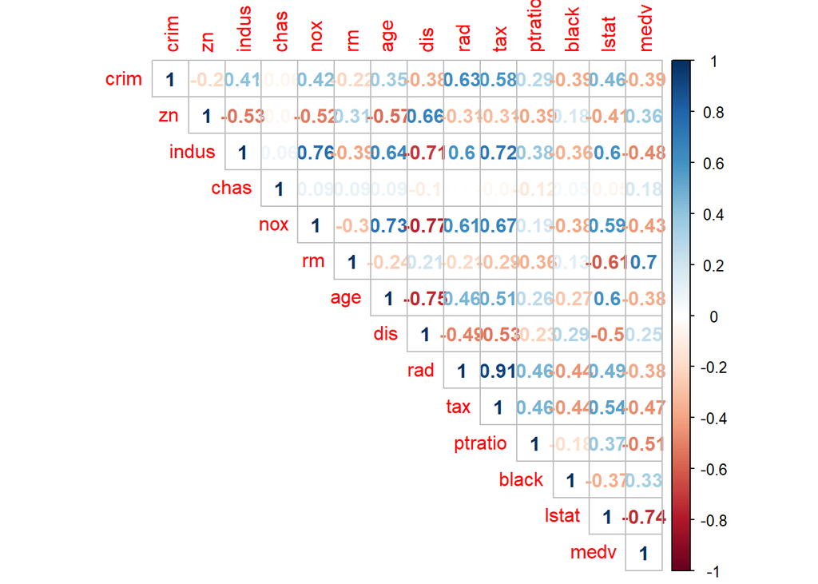

```r
corrplot(cor(df),method='number',type='upper')
```

medv는 보스턴의 집 가격으로 종속변수이다. 가장 오른편의 숫자들로 종속변수와 각 독립변수들 간의 상관관계를 알 수 있다. lstat, rm이 medv에 큰 영향을 주며, lstat의 경우 값이 작을수록, rm의 경우 값이 높을수록 보스턴의 집 가격이 높은 경향을 보임을 알 수 있다. 이 때 주의해야할 점은 독립변수들 간의 밀접한 상관성입니다. 밀접한 상관성이 있는 것은 다중공산성을 피하기 위해 주의해야합니다.

2. 아래와 같이 종속변수로 사용할 medv와 이외 변수 간의 관계 파악을 위한 scatterplot 및 회귀 추세선을 그려보세요. (gather 이용 시 편리, 색 : lightblue)

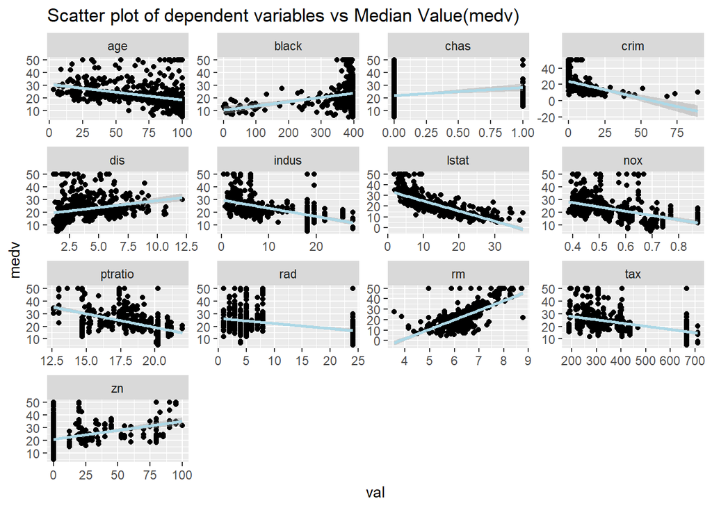

```r
df%>%gather('age','black','chas','crim','dis','indus','lstat','nox','ptratio','rad','rm','tax','zn',key='column',value='val')%>%ggplot(aes(x=val, y=medv)) +
  geom_point(color='black') +
  stat_smooth(method = 'lm', color='lightblue')+
  facet_wrap(~column,scales = 'free')+
  ggtitle("Scatter plot of dependent variables vs Median Value(medv)")
```

3. 데이터를 train/test 데이터를 7:3으로 나누세요 (1234로 시드 고정 필수).

```r
set.seed(1234)
train_idx=createDataPartition(df$medv, p=.7, times=1, list=FALSE)
train=df[train_idx,]
test=df[-train_idx,]
#종속변수의 요인별 비율만큼 층화랜덤추출
```

3-2. train 데이터로 medv를 종속변수로 하고 나머지를 모두 독립 변수로 하는 회귀 모형을 만든 후 간단히 결과를 해석한 후, test에 대한 RMSE를 구하세요.

```r
x_train=train[,-14]
y_train=as.data.frame(train[,14])
names(y_train)=c("medv")
train_y=y_train %>% unlist %>% as.vector
x_test=test[,-14]
y_test=as.data.frame(test[,14])
names(y_test)=c("medv")
test_y=y_test %>% unlist %>% as.vector




all_new_lm = lm(medv ~ ., data=train)
all_new_lm %>% summary
```

```
##
## Call:
## lm(formula = medv ~ ., data = train)
##
## Residuals:
##      Min       1Q   Median       3Q      Max
## -11.3323  -2.8734  -0.6592   1.9638  23.5680
##
## Coefficients:
##               Estimate Std. Error t value Pr(>|t|)
## (Intercept)  39.141877   6.297934   6.215 1.49e-09 ***
## crim         -0.134206   0.038868  -3.453 0.000624 ***
## zn            0.050246   0.017306   2.903 0.003931 **
## indus        -0.007431   0.078241  -0.095 0.924393
## chas          2.940348   1.104224   2.663 0.008115 **
## nox         -17.620358   4.847780  -3.635 0.000321 ***
## rm            3.441546   0.509100   6.760 5.97e-11 ***
## age           0.015060   0.016439   0.916 0.360236
## dis          -1.482356   0.240633  -6.160 2.04e-09 ***
## rad           0.397221   0.083820   4.739 3.16e-06 ***
## tax          -0.013384   0.004781  -2.800 0.005406 **
## ptratio      -0.973610   0.161098  -6.044 3.94e-09 ***
## black         0.009445   0.003302   2.860 0.004494 **
## lstat        -0.593385   0.059098 -10.041  < 2e-16 ***
## ---
## Signif. codes:  0 '***' 0.001 '**' 0.01 '*' 0.05 '.' 0.1 ' ' 1
##
## Residual standard error: 4.941 on 342 degrees of freedom
## Multiple R-squared:  0.735,  Adjusted R-squared:  0.7249
## F-statistic: 72.97 on 13 and 342 DF,  p-value: < 2.2e-16
```

```r
pred_all_lm=predict(all_new_lm, test)
all_lm_rmse=RMSE(pred_all_lm, test_y)
all_lm_rmse
```

```
## [1] 4.423034
```

3-3.모델의 RMSE를 낮출 수 있는 방법에 대해 간략히 설명해 주세요. 편향과 분산을 낮추면 된다. 즉, 과적합과 과소적합을 피하면 되며 이의 한 방법으로 교차검증을 생각해볼 수 있다.(RMSE는 MSE에 루트를 씌운 것이며 MSE는 평균제곱오차로 n개를 표본추출했을 때, 표본평균에서 실제값을 뺀 값을 제곱하고 이를 합한 값을 n으로 나눈 것이다.)

4. 적합한 회귀모형의 계수에 대해 아래와 같이 시각화 해주세요 (색 : red, yellow, blue)

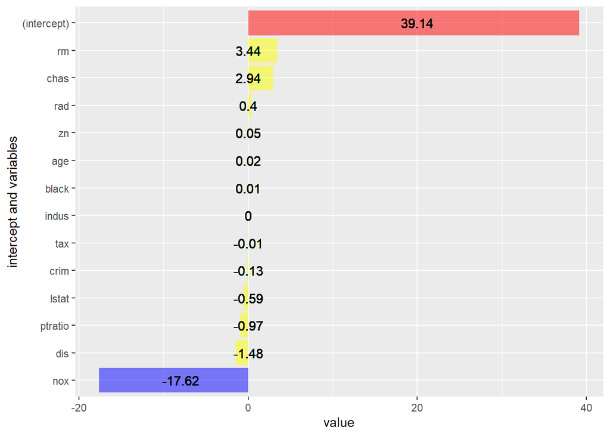

```r
linear_coef<-summary(all_new_lm)$coefficients
linear_coef<-as.data.frame(linear_coef)
meaning<-c('(intercept)','crim','zn','indus','chas','nox','rm','age','dis','rad','tax','ptratio','black','lstat')
linear_coef$meaning<-meaning
linear_coef%>% ggplot(aes(x=reorder(meaning,Estimate),y=Estimate,fill=meaning))+
  geom_bar(stat='identity',alpha=0.5)+coord_flip()+
  xlab('intercept and variables')+
  ylab('value')+
  geom_text(x='(intercept)',y=20,label='39.14')+
  geom_text(x='crim',y=0,label='-0.13')+
  geom_text(x='zn',y=0,label='0.05')+
  geom_text(x='indus',y=0,label='0')+
  geom_text(x='chas',y=0,label='2.94')+
  geom_text(x='nox',y=-8,label='-17.62')+
  geom_text(x='rm',y=0,label='3.44')+
  geom_text(x='age',y=0,label='0.02')+
  geom_text(x='dis',y=0,label='-1.48')+
  geom_text(x='rad',y=0,label='0.4')+
  geom_text(x='tax',y=0,label='-0.01')+
  geom_text(x='ptratio',y=0,label='-0.97')+
  geom_text(x='black',y=0,label='0.01')+
  geom_text(x='lstat',y=0,label='-0.59')+
  scale_fill_manual(values = c( 'red', 'yellow','yellow','yellow','yellow','yellow','yellow','yellow','blue','yellow','yellow','yellow','yellow','yellow'))+
  theme(legend.title = element_blank()) +
  theme(legend.position = 'none')
```